# 1. Multilevel modeling

Edoardo Cortolezzis

2025-01-15

# Exercise 1: Multilevel modeling

**Consider the dataset nyc_arrests.txt related to the police stops (you find the dataset in the Exam section in the Moodle page): for further details, see G& H book, Chapter 15, and lecture notes about hierarchical models, slides 123–128.**

## Fit the model (24) in the notes from a Bayesian and a frequentist point of view, using rstanarm/rstan and lme4 packages.

### Dataset loading and data exploration

First, let’s load the data and take a look at it.

```r
data <- read.table("datasets/nyc_arrests.txt", header = TRUE, sep = " ", skip = 6) # the first 5 written lines are comments about the dataset

# adding a small value to the zero values of past.arrests to avoid numerical errors
data$past.arrests <- data$past.arrests + 0.0001
# Correct the zero values for numerical errors <---- da capire. Se metto 0 nella log likelihod mi da errore <- questa parte la posso riscrivere più avanti

summary(data)
```

```
##      stops           pop          past.arrests          precinct       eth
##  Min.   :   0   Min.   :   321   Min.   :   0.0001   Min.   : 1   Min.   :1
##  1st Qu.:  26   1st Qu.:  6844   1st Qu.:  53.0001   1st Qu.:19   1st Qu.:1
##  Median :  72   Median : 18004   Median : 124.0001   Median :38   Median :2
##  Mean   : 146   Mean   : 30105   Mean   : 262.8212   Mean   :38   Mean   :2
##  3rd Qu.: 173   3rd Qu.: 46669   3rd Qu.: 287.5001   3rd Qu.:57   3rd Qu.:3
##  Max.   :1755   Max.   :184345   Max.   :2655.0001   Max.   :75   Max.   :3
##      crime
##  Min.   :1.00
##  1st Qu.:1.75
##  Median :2.50
##  Mean   :2.50
##  3rd Qu.:3.25
##  Max.   :4.00
```

1. **stops**: Number of police stops recorded;
2. **pop**: Population size in the precinct;
3. **past.arrests**: Measure of past arrests;
4. **precinct**: Precinct number, ranging from 1 to 75;
5. **eth**: Ethnicity type: 1 for ‘Black’, 2 for ‘Hispanic’ and 3 for ‘White’;
6. **crime**: Crime type: 1 for ‘Violent crimes’, 2 for ‘Weapons crimes’, 3 for ‘Property crimes’ and 4 for ‘Drug crimes’.

Variables distributions:

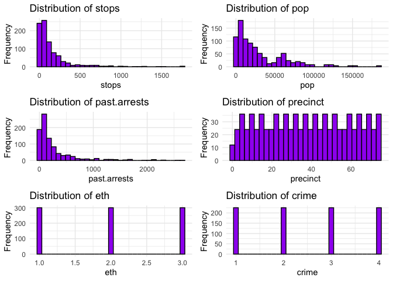

For each of the 4 crime, we can check the Stops distributions:

- grouped by precinct:

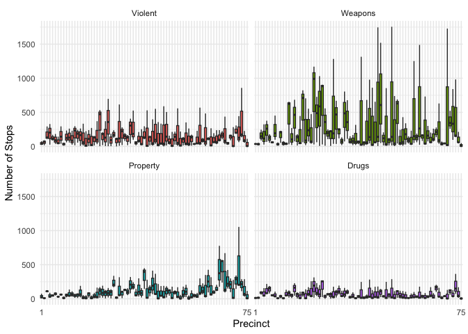

- grouped by ethnicity:

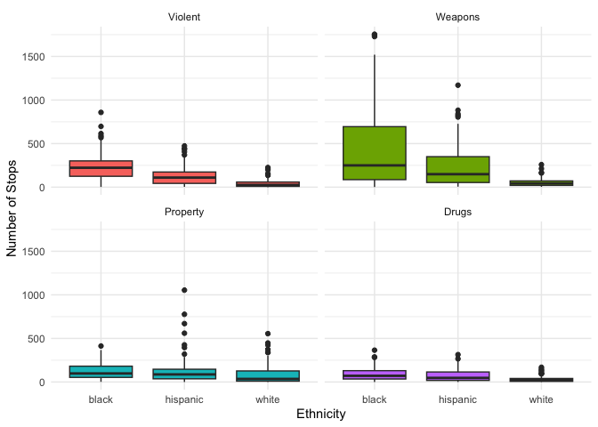

From this plots we may infer that the number of stops is higher in some precint, depending on the crime type, and that there may be some higher stop rates for ‘Black’ and ‘Hispanic’, compared to ‘White’.

We’ll take this info into account and fit model (24). A Poisson multilevel model that estimates the number of stops, while considering the variations among precincts and ethnic groups.

Model (24):
$$y_{ep} \sim \text{Poisson}
\left( \frac{15}{12} u_{ep} e^{\mu + \alpha_e + \beta_p + \epsilon_{ep}}
\right)$$
$$\alpha_e \sim N(0,
\sigma^2_{\alpha}) \\
\beta_p \sim N(0, \sigma^2_{\beta}) \\
\epsilon_{ep} \sim N(0, \sigma^2_{\epsilon})$$

where:

- $y_{ep}$ corresponds to stops: the number of stops in the precinct for the ethnicity relative to the crime;
- $u_{ep}$ corresponds to past.arrests: the number of past arrests in the precinct p for the ethnicity e;
- $u$ corresponds to the fixed effect: the intercept at the individual level;
- $\alpha_e$ and $\beta_p$ correspond to the ethnic and precinct random effects, respectively;
- $\epsilon_{ep}$ corresponds to the error term to account for overdispersion.

### Models Fitting:

```r
# Define the models lists to store the models
fr_models <- list()
ba_models <- list()

# Fit the models for each crime
for (i in 1:4){
cat("\nFitting the Frequentist model for crime ", i, "\n")
# Fit the frequentist model using glmer
fr_models[[i]] <- glmer(stops ~ 1 + (1|eth) + (1|precinct) + (1|eth:precinct),
                    offset = log((15/12) * past.arrests),
                    data = data,
                    subset = (crime == i),
                    family = poisson())

cat("\nFitting the Bayesian model for crime ", i, "\n")
# Fit the bayesian model using stan_glmer
ba_models[[i]] <- stan_glmer(stops ~ 1 + (1|eth) + (1|precinct) + (1|eth:precinct),
                    offset = log((15/12) * past.arrests),
                    data = data,
                    subset = (crime == i),
                    prior = normal(),
                    family = poisson(),
                    seed = 42)
}
```

## Provide the estimates (also from a graphical perspective) and comment the results. Hint: use the bayesplot package when you can.

After fitting the models, we can extract the estimates and visualize them using the `bayesplot` package.

- Estimates:

```
## Frequentist model for crime:  1
## Generalized linear mixed model fit by maximum likelihood (Laplace
##   Approximation) [glmerMod]
##  Family: poisson  ( log )
## Formula: stops ~ 1 + (1 | eth) + (1 | precinct) + (1 | eth:precinct)
##    Data: data
##  Offset: log((15/12) * past.arrests)
##  Subset: (crime == i)
##       AIC       BIC    logLik  deviance  df.resid
##  2314.932  2328.596 -1153.466  2306.932       221
## Random effects:
##  Groups       Name        Std.Dev.
##  eth:precinct (Intercept) 0.3558
##  precinct     (Intercept) 0.5129
##  eth          (Intercept) 0.3814
## Number of obs: 225, groups:  eth:precinct, 225; precinct, 75; eth, 3
## Fixed Effects:
## (Intercept)
##       -1.08
##
## Bayesian model for crime:  1
## stan_glmer
##  family:       poisson [log]
##  formula:      stops ~ 1 + (1 | eth) + (1 | precinct) + (1 | eth:precinct)
##  observations: 225
##  subset:       (crime == i)
## ------
##             Median MAD_SD
## (Intercept) -1.1    0.3
##
## Error terms:
##  Groups       Name        Std.Dev.
##  eth:precinct (Intercept) 0.36
##  precinct     (Intercept) 0.52
##  eth          (Intercept) 0.81
## Num. levels: eth:precinct 225, precinct 75, eth 3
##
## ------
## * For help interpreting the printed output see ?print.stanreg
## * For info on the priors used see ?prior_summary.stanreg
```

[output cut: 117 more lines]

```
## (Intercept) -2.0    0.2
##
## Error terms:
##  Groups       Name        Std.Dev.
##  eth:precinct (Intercept) 0.46
##  precinct     (Intercept) 0.86
##  eth          (Intercept) 0.41
## Num. levels: eth:precinct 225, precinct 75, eth 3
##
## ------
## * For help interpreting the printed output see ?print.stanreg
## * For info on the priors used see ?prior_summary.stanreg
##
##
## ﹌﹌﹌﹌﹌﹌﹌﹌﹌﹌﹌﹌﹌﹌﹌﹌﹌﹌﹌﹌﹌﹌﹌﹌﹌﹌﹌﹌﹌﹌﹌﹌﹌﹌﹌﹌﹌﹌﹌﹌﹌﹌﹌﹌﹌﹌
```

- Plots:
  - Eth

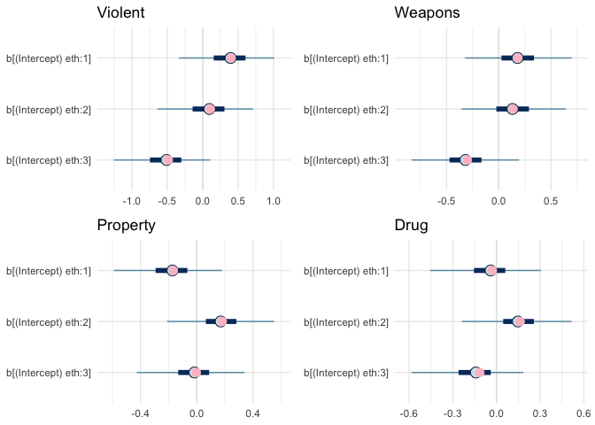

  - Precint 1 to 5 and 71 to 75

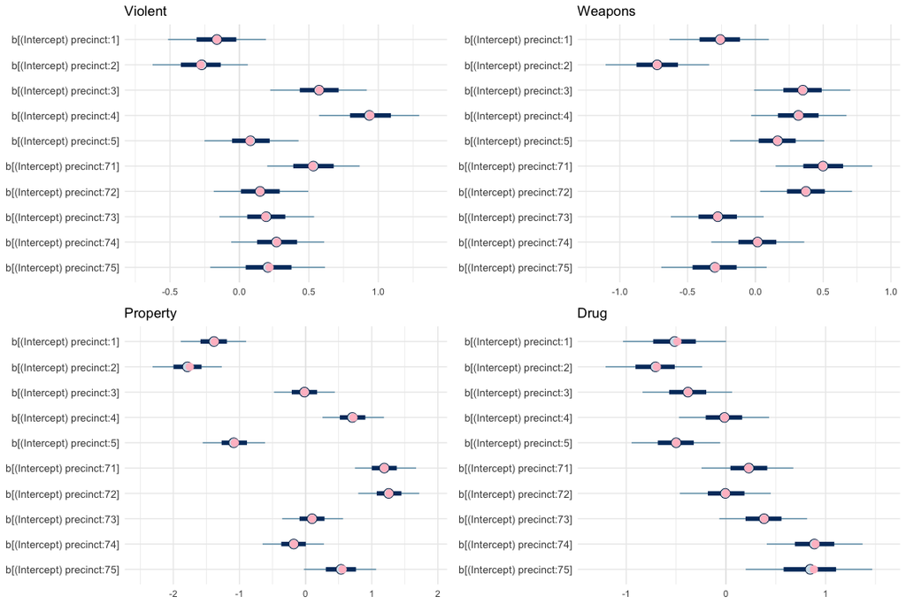

  - Eth:Precint

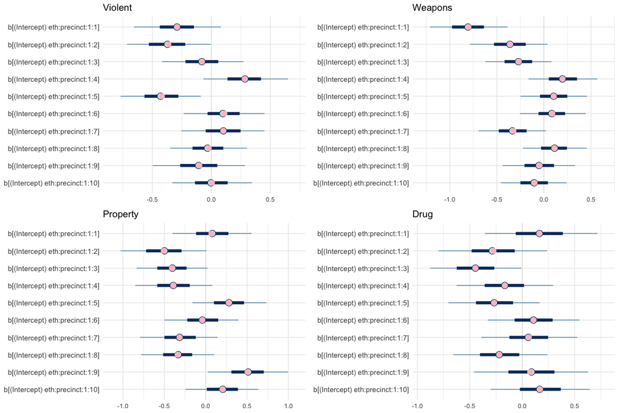

## Fit directly a negative binomial model using rstanarm/rstan and compare it with the previous estimates.

To address overdispersion as an alternative to the $\epsilon_{ep}$ term in the poisson model, we can fit a negative binomial model. Following a similar approach as before, we will use `rstanarm` to fit this model and compare it with the previous estimates:

```r
nb_models <- list()
for (i in 1:4){
cat("Fitting the Negative Binomial model for crime ", i,"\n")
nb_models[[i]] <- stan_glmer(stops ~ 1 + (1|eth) + (1|precinct),
                             offset = log((15/12) * past.arrests),
                             data = data,
                             subset = (crime == i),
                             prior = normal(),
                             family = neg_binomial_2(),
                             seed = 42)
}
```

As before, we can take a look at the estimates of these models and compare them with the previous ones:

[output not shown]

[output cut: 137 more lines]

[output not shown]

We can also visualize and compare the estimates’ plots of both the poisson and the negative binomial models:

- Density Plots:
  - Poisson:

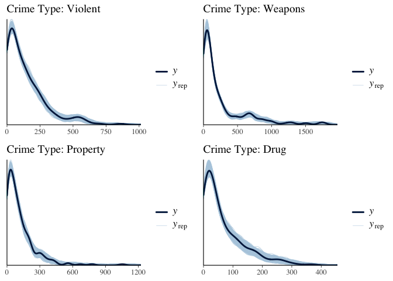

  - Negative Binomial:

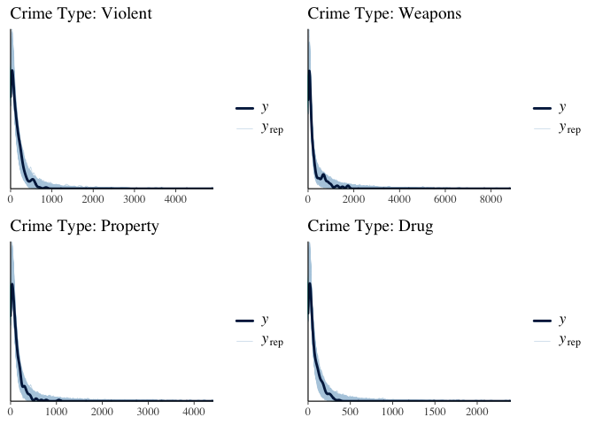

It looks like the NB model overestimates low number of stops and spread more as the number of stops increases. On the other hand, the Poisson model seems to be a better fit for the data.

- 2D Stats Plots:
  - Poisson:

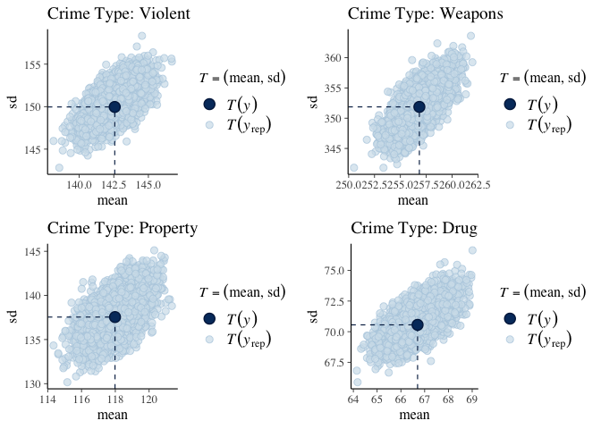

  - Negative Binomial:

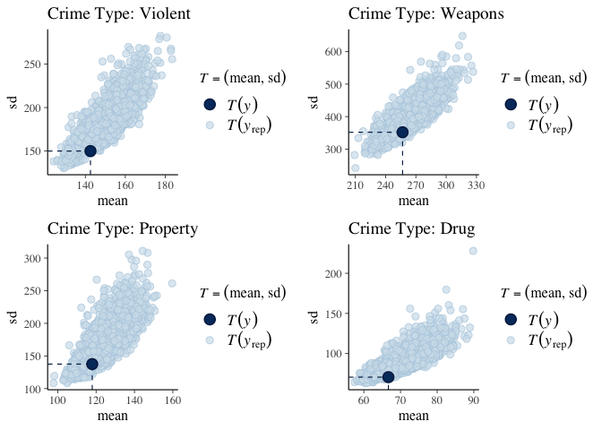

Even from these plots we can see how the Poisson model seems to be a better fit for the data, as it captures the distribution of the number of stops better than the Negative Binomial model.

## Compare models in terms of predictive information criteria.

To compare the models, we can use the Leave-One-Out Cross-Validation (LOOIC), available via the `loo` package. Models with lower LOOIC values generally exhibit better predictive accuracy on unseen data.

- LOOIC values:

```
## Crime  1
##  - LOOIC for Negative Binomial model:  2239.042
##  - LOOIC for Poisson model:  1897.678
## Crime  2
##  - LOOIC for Negative Binomial model:  2443.391
##  - LOOIC for Poisson model:  1989.478
## Crime  3
##  - LOOIC for Negative Binomial model:  2298.351
##  - LOOIC for Poisson model:  1911.281
## Crime  4
##  - LOOIC for Negative Binomial model:  2022.761
##  - LOOIC for Poisson model:  1719.416
```

- LOOIC values plotted:

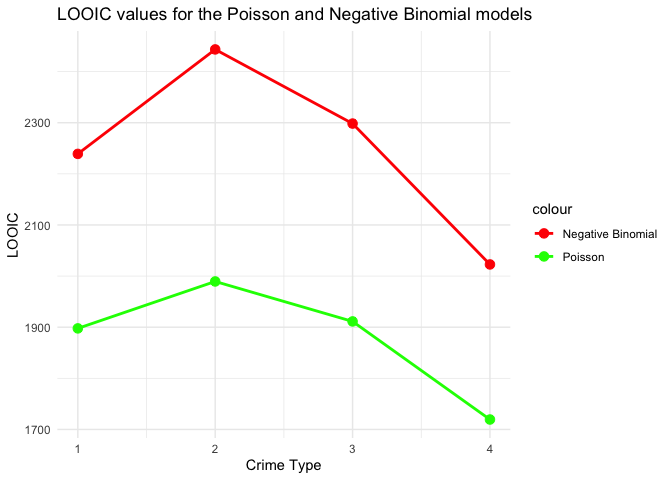

The lower values of LOOIC for the Poisson model suggest that it has better predictive accuracy compared to the Negative Binomial model in all crime types.

## Divide the dataset in training/test and make some predictions.

We’ll divide the dataset in training and test set, fit the models on `train_data` (80% of the data) and make some predictions on `test_data` (20% of the data).

First, we’ll split the data into training and testing sets:

```r
# Set the seed for reproducibility
set.seed(42)
train_indices <- sample(seq_len(nrow(data)), size = 0.8 * nrow(data))
# Create training and testing sets
train_data <- data[train_indices, ]
test_data <- data[-train_indices, ]
```

Then, we can train the Poisson and the Negative Binomil models on the training set:

```r
# Fit the models on the training set
bayesian_models_train <- list()
nb_models_train <- list()
for (i in 1:4){
  cat("\nFitting the Bayesian model for crime ", i, " on the training set\n")
  bayesian_models_train[[i]] <- stan_glmer(stops ~ 1 + (1|eth) + (1|precinct) + (1|eth:precinct),
                                          offset = log((15/12) * past.arrests),
                                          data = train_data,
                                          subset = (crime == i),
                                          prior = normal(),
                                          family = poisson(),
                                          seed = 42)
  cat("\nFitting the Negative Binomial model for crime ", i, " on the training set\n")
  nb_models_train[[i]] <- stan_glmer(stops ~ 1 + (1|eth) + (1|precinct),
                                    offset = log((15/12) * past.arrests),
                                    data = train_data,
                                    subset = (crime == i),
                                    prior = normal(),
                                    family = neg_binomial_2(),
                                    seed = 42)
}
```

Finally we can make some predictions on the test set and evaluate the models:

Once the predictions are made, we can evaluate them using the RMSE and the MAE metrics:

```
## Overall Results:
## Poisson Model - MAE: 163.6833
```

```
##
## Poisson Model - RMSE: 301.7796
```

```
##
## Negative Binomial Model - MAE: 209.2333
```

```
##
## Negative Binomial Model - RMSE: 400.1642
```

From these results we may be tempted to say that the Poisson model is better than the Negative Binomial model.

```
## Mean values of these metrics for the Poisson model over the first 20 seeds:
##  - MAE:  201.2911
##  - RMSE:  377.706
```

```
##
## Mean values of these metrics for the Negative Binomial model over the first 20 seeds:
##  - MAE:  200.7041
##  - RMSE:  387.5385
```

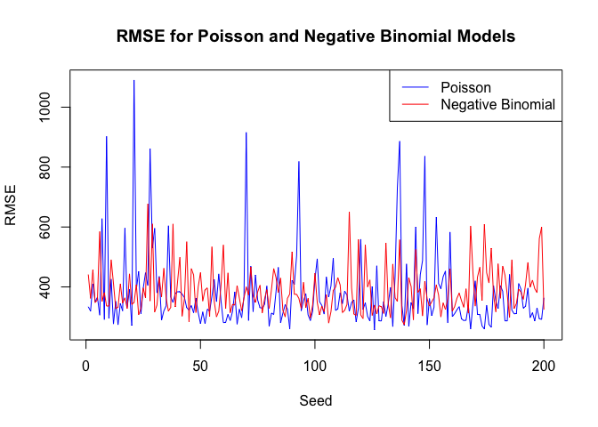

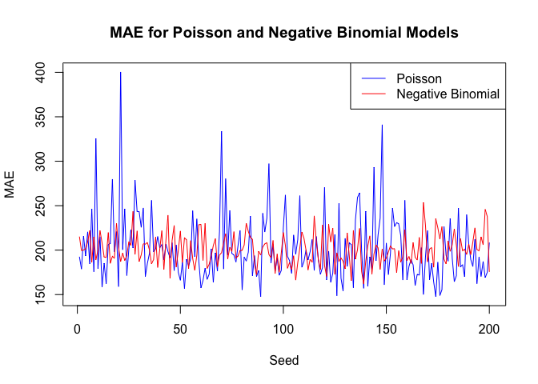

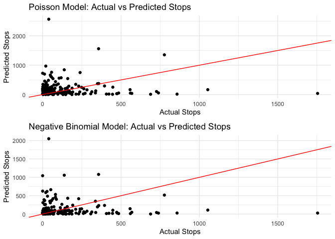

Nonetheless, is evident how both models exhibit limitations in achieving highly accurate predictions. This suggests a need for further investigation and exploration of alternative models that may provide improved fit.

## Extend the model: write a modeling extension (fit is not required) where a further continuous covariate income_ethnicity, expressing an average income for the ethnicity e in New-York City, is available. (Hint: there is not a unique way to incorporate it). Finally, discuss the eventual sign of the estimated coefficient from a “socio-political” perspective.

An alternative model, that incorporates the continuous covariate $\text{income}_e$, could be:

- Poisson model:
  $$y_{ep} \sim
  \text{Poisson} \left( \frac{15}{12} u_{ep} e^{\mu + \alpha_e + \beta_p +
  \epsilon_{ep} + \gamma_e \cdot \text{income}_e} \right) \\
  \alpha_e \sim N(0, \sigma^2_{\alpha}) \\
  \beta_p \sim N(0, \sigma^2_{\beta}) \\
  \epsilon_{ep} \sim N(0, \sigma^2_{\epsilon}) \\
  \gamma_e \sim N(0, \sigma^2_{\gamma}) \\$$
- Negative Binomial Model:
  $$y_{ep} \sim
  \text{NB} \left( \frac{15}{12} u_{ep} e^{\mu + \alpha_e + \beta_p +
  \gamma_e \cdot \text{income}_e}, \omega_{ep} \right) \\
  \alpha_e \sim N(0, \sigma^2_{\alpha}) \\
  \beta_p \sim N(0, \sigma^2_{\beta}) \\
  \gamma_e \sim N(0, \sigma^2_{\gamma}) \\$$

where $\omega_{ep}$ is the overdispersione parameter of the NB model.